# Practical Machine Learning Project Report

Punyashree PB

### PROBLEM STATEMENT:

The goal of this project is to predict or classify new exercises using a subset of predictiors from the data (Predicting the `classe` vairalbe), using data recorded from four types of body sensors during body building exercises. After applying various data cleanup and preprossesing techniques, a training model was built to predict 20 observations from a test dataset. In this document, explained the methods and results obtained.

### DATA:

The training data for this project are available here:

https://d396qusza40orc.cloudfront.net/predmachlearn/pml-training.csv

The test data are available here:

https://d396qusza40orc.cloudfront.net/predmachlearn/pml-testing.csv

### METHODOLOGY

#### Loading Required Packages

```r
library(rpart)
library(caret)
library(randomForest)
```

#### Loading Data:

```r
train <- read.csv("pml-training.csv", na.strings=c("", "NA", "NULL"))
test <- read.csv("pml-testing.csv", na.strings=c("", "NA", "NULL"))
```

#### Data Pre-processing

Lets remove the columns containing *NA’s* from the data

```r
train <-train[,colSums(is.na(train)) == 0]
test <-test[,colSums(is.na(test)) == 0]
```

Lets remove the unwanted columns fromt he data

```r
train   <-train[,-c(1:7)]
test <-test[,-c(1:7)]
```

#### Data Partition

Lets partition the train data in to training and validation set.

```r
trainset <- createDataPartition(train$classe, p = 0.8, list = FALSE)
Training <- train[trainset, ]
Validation <- train[-trainset, ]
```

#### Histogram Plot

Lets draw a simple histogram plot for the prediction variable.

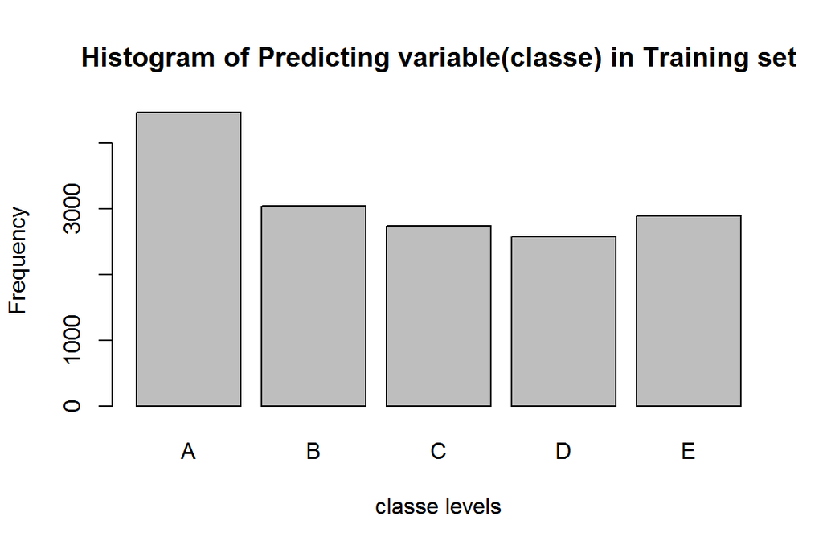

```r
plot(Training$classe, col="gray",
     main="Histogram of Predicting variable(classe) in Training set",
     xlab="classe levels", ylab="Frequency")
```

#### Building Model

Lets use reandom forest for building the model.

```r
rfMod <- randomForest(classe ~. , data=Training, method="class")
rfMod
```

```
##
## Call:
##  randomForest(formula = classe ~ ., data = Training, method = "class")
##                Type of random forest: classification
##                      Number of trees: 500
## No. of variables tried at each split: 7
##
##         OOB estimate of  error rate: 0.38%
## Confusion matrix:
##      A    B    C    D    E  class.error
## A 4462    2    0    0    0 0.0004480287
## B   11 3024    3    0    0 0.0046082949
## C    0   12 2724    2    0 0.0051132213
## D    0    0   22 2550    1 0.0089389817
## E    0    0    2    5 2879 0.0024255024
```

#### Cross Validation.

Lets cross validate using the Validation set

```r
rfPred <- predict(rfMod, Validation, type = "class")
confusionMatrix(rfPred, Validation$classe)
```

```
## Confusion Matrix and Statistics
##
##           Reference
## Prediction    A    B    C    D    E
##          A 1115    4    0    0    0
##          B    1  754    5    0    0
##          C    0    1  679    5    1
##          D    0    0    0  637    2
##          E    0    0    0    1  718
##
## Overall Statistics
##
##                Accuracy : 0.9949
##                  95% CI : (0.9921, 0.9969)
##     No Information Rate : 0.2845
##     P-Value [Acc > NIR] : < 2.2e-16
##
##                   Kappa : 0.9936
##  Mcnemar's Test P-Value : NA
##
## Statistics by Class:
##
##                      Class: A Class: B Class: C Class: D Class: E
## Sensitivity            0.9991   0.9934   0.9927   0.9907   0.9958
## Specificity            0.9986   0.9981   0.9978   0.9994   0.9997
## Pos Pred Value         0.9964   0.9921   0.9898   0.9969   0.9986
## Neg Pred Value         0.9996   0.9984   0.9985   0.9982   0.9991
## Prevalence             0.2845   0.1935   0.1744   0.1639   0.1838
## Detection Rate         0.2842   0.1922   0.1731   0.1624   0.1830
## Detection Prevalence   0.2852   0.1937   0.1749   0.1629   0.1833
## Balanced Accuracy      0.9988   0.9958   0.9953   0.9950   0.9978
```

The Cross validation accuracy is **99.5%** so the out of sample error is **0.5%**, which confirms our model has performed good.

#### Test Prediction

Lets predict the test set using the our model *rfMod*

```r
testPred <- predict(rfMod, test, type="class")
testPred
```

```
##  1  2  3  4  5  6  7  8  9 10 11 12 13 14 15 16 17 18 19 20
##  B  A  B  A  A  E  D  B  A  A  B  C  B  A  E  E  A  B  B  B
## Levels: A B C D E
```

Lets save the output as txt files as mentioned in the submission instructions using the following code, which was given as the submission instructions.

```r
answers <- as.character(testPred)

pml_write_files = function(x){
    n = length(x)
    for(i in 1:n){
        filename = paste0("problem_id_",i,".txt")
        write.table(x[i], file=filename, quote=FALSE, row.names=FALSE,
                    col.names=FALSE)
    }
}

pml_write_files(answers)
```

### CONCLUSION

1. Used Random Forest to create the model.
2. Cross Validation is done and the out of sample error is found out to be **0.5%** which is pretty good model.